# Wide(r) and long(er) data formats - tranformations using `{tidyr}`

## Motivation

> Data scientists, according to interviews and expert estimates, spend from 50 percent to 80 percent of their time mired in the mundane labor of collecting and preparing data, before it can be explored for useful information.

This tutorial covers selected *basics topics* of data handling based on the `tidyr` package.

- General data handling & processing
- Simple `ggplot2` plots (long format required)

Usage for transforming data from wide(r) to long(er) formats and vice versa: * Eurostat: data in long format, wide format often required for regression analysis * Panel data analysis

## Wide(r) format

- For **cross sections**, row corresponds to `i-th` individual (person, firm, etc.) and each column corresponds to a variable (age, height, weight).
- For **time series**, row corresponds to a time period (year, quarter, day, etc.) and each column corresponds to a variable (GDP per capita, Unemployment rate).
- Wide format is used in many `R`-based applications: linear regression, VAR models, etc.

## Long(er) format

- For **cross sections**, data is stretched so that a single individual may occupy multiple rows.
- The same applies to **time series**

## `pivot_longer()` and `pivot_wider()` commands

- `pivot_longer()` converts wider format to longer
- `pivot_wider()` converts longer format to wider

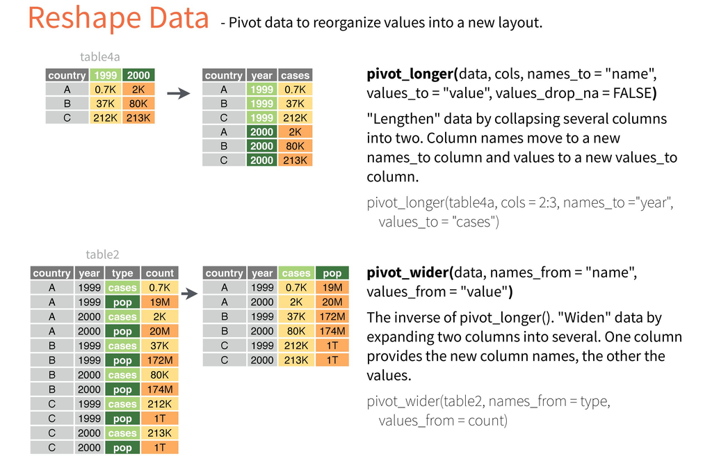

## GDP & Time Series Example (single-variable example)

### GDP - Wider format

```r
GDPwide <- data.frame(
  Year = c(2009:2018),
  GER = c(411,723,325,456,579,612,709,513,527,379),
  FRA = c(123,300,400,500,600,654,789,906,413,567),
  USA = c(957,1000,569,896,956,1345,780,599,1023,678)
)
GDPwide # artifical/made-up data used here
```

```
##    Year GER FRA  USA
## 1  2009 411 123  957
## 2  2010 723 300 1000
## 3  2011 325 400  569
## 4  2012 456 500  896
## 5  2013 579 600  956
## 6  2014 612 654 1345
## 7  2015 709 789  780
## 8  2016 513 906  599
## 9  2017 527 413 1023
## 10 2018 379 567  678
```

- Above is the **wider format** - GDP data are shown for different states and years
- In **longer format** (below), the same data are shown, yet each `Year` and `Country` combination is on a separate row of the dataset.
  - Columns `Year`, `State` and `GDP` are used to display the same data as in wider format.
  - Note that `State` and `GDP` *variables* (i.e. columns in the longer-format dataset) need to be created to produce the longer format (such *variables* do not exist in the wider format dataset)

### GDP - Longer format (same data)

```
##    Year State  GDP
## 1  2009   GER  411
## 2  2009   FRA  123
## 3  2009   USA  957
## 4  2010   GER  723
## 5  2010   FRA  300
## 6  2010   USA 1000
## 7  2011   GER  325
## 8  2011   FRA  400
## 9  2011   USA  569
## 10 2012   GER  456
## 11 2012   FRA  500
## 12 2012   USA  896
## 13 2013   GER  579
## 14 2013   FRA  600
```

[output cut: 16 more lines]

### Task 1: Convert `GDPwide` to longer format

```r
GDPwide # repeated from above for readability
```

```
##    Year GER FRA  USA
## 1  2009 411 123  957
## 2  2010 723 300 1000
## 3  2011 325 400  569
## 4  2012 456 500  896
## 5  2013 579 600  956
## 6  2014 612 654 1345
## 7  2015 709 789  780
## 8  2016 513 906  599
## 9  2017 527 413 1023
## 10 2018 379 567  678
```

`pivot_longer(GDPwide, cols = 2:4, names_to = "State", values_to = "GDP")`

- `GDPwide` dataframe to reshape - convert to longer format
- `cols = 2:4` numeric indexes of columns *to collapse* into a single column.
- `names_to = "State"` is the name of the new *key* column - a new *variable* (can be any character string you supply). Values in the “State” column are based on column names of the columns being collapsed (`2:4`).
  - *variable*-names in the wider format dataframe (State IDs: `GER`,`FRA`,`USA`) are used as “entries” (keys) in the new column (hence variable name `State`).
- `values_to = "GDP"` name of the new value column (can be any character string you supply)
- Please note that column `Year` (1st column) is left out from the syntax (“grey column” as in the illustration above).

```r
GDPlong <- pivot_longer(GDPwide, cols = 2:4, names_to = "State", values_to = "GDP")
print.data.frame(GDPlong)
```

```
##    Year State  GDP
## 1  2009   GER  411
## 2  2009   FRA  123
## 3  2009   USA  957
## 4  2010   GER  723
## 5  2010   FRA  300
## 6  2010   USA 1000
## 7  2011   GER  325
## 8  2011   FRA  400
## 9  2011   USA  569
## 10 2012   GER  456
## 11 2012   FRA  500
## 12 2012   USA  896
## 13 2013   GER  579
## 14 2013   FRA  600
```

[output cut: 16 more lines]

### Task 2: Convert `GDPlong` to wider format

`pivot_wider(GDPlong, names_from = "State", values_from = "GDP")`

- `GDPlong` dataframe to reshape - convert to wider format
- `names_from = "State"` column to use for keys (new column names, i.e. new *variable names*)
- `values_from = "GDP"` column to extract values from (will enter into data-cells in the new (wider) dataframe)
- Please note that column `Year` is left out from the syntax (“grey column” as in the illustration above).

```r
GDPwide_2 <- pivot_wider(GDPlong, names_from = "State", values_from = "GDP")
print.data.frame(GDPwide_2)
```

```
##    Year GER FRA  USA
## 1  2009 411 123  957
## 2  2010 723 300 1000
## 3  2011 325 400  569
## 4  2012 456 500  896
## 5  2013 579 600  956
## 6  2014 612 654 1345
## 7  2015 709 789  780
## 8  2016 513 906  599
## 9  2017 527 413 1023
## 10 2018 379 567  678
```

- Columns in `GDPwide_2` can be ordered alphabetically, using the `names_sort = T` argument.
- A *transposed* output can be produced as follows

```r
pivot_wider(GDPlong, names_from = "Year", values_from = "GDP")
```

```
## # A tibble: 3 x 11
##   State `2009` `2010` `2011` `2012` `2013` `2014` `2015` `2016` `2017` `2018`
##   <chr>  <dbl>  <dbl>  <dbl>  <dbl>  <dbl>  <dbl>  <dbl>  <dbl>  <dbl>  <dbl>
## 1 GER      411    723    325    456    579    612    709    513    527    379
## 2 FRA      123    300    400    500    600    654    789    906    413    567
## 3 USA      957   1000    569    896    956   1345    780    599   1023    678
```

- However, this type of data frame formatting is seldom useful.

#### Data in longer format can be used for plotting by `{ggplot2}`.

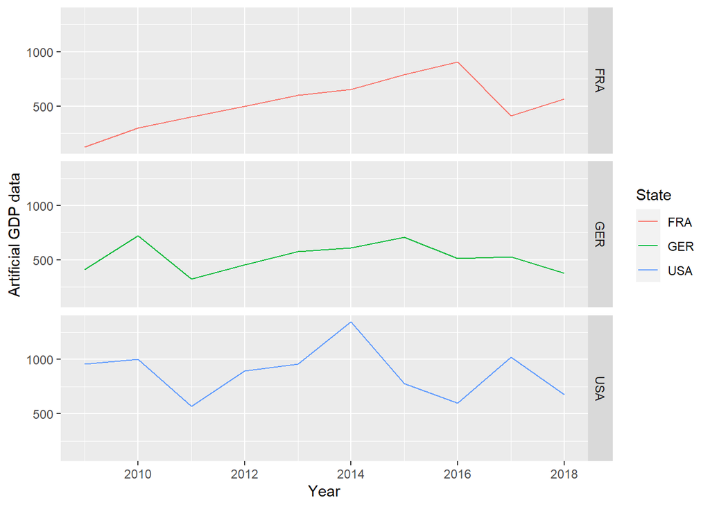

```r
# In this example, we plot GDP only,
# so go back to the GDPlong dataset
Plot1 <- ggplot(data = GDPlong, aes(x = Year, y = GDP))+
  geom_line(aes(color=State))+
  xlab("Year")+ylab("Artificial GDP data")+
  facet_grid(State~.)
Plot1
```

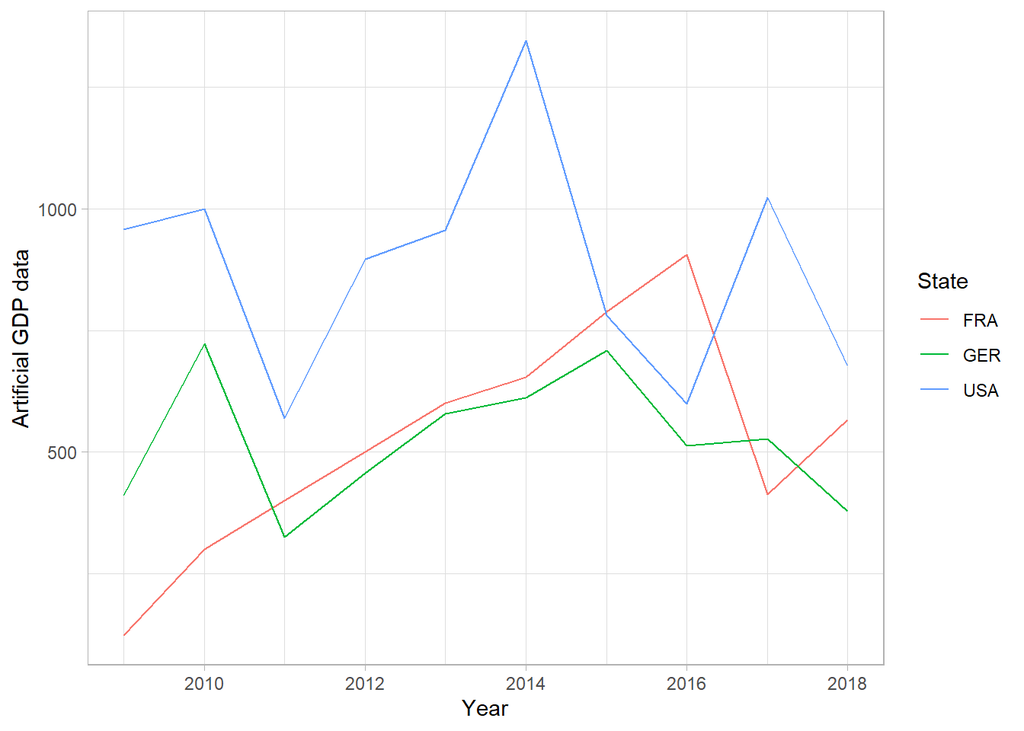

```r
Plot2 <- ggplot(data = GDPlong, aes(x = Year, y = GDP))+
  geom_line(aes(color=State))+
  xlab("Year")+ylab("Artificial GDP data")+
  theme_light() # remove faceting, include theme "light"
Plot2
```

## Supervised work - Excercise 1

The following wide-format dataset contains GDP per capita for Spain (source: Eurostat)

- Euro per inhabitant in percentage of the EU average (100 = EU’s average in a given year)
- 2005 - 2016 data
- Measured at the [NUTS2 level](https://en.wikipedia.org/wiki/NUTS_statistical_regions_of_Spain)

```r
GDPSpain <- read.csv("datasets/GDP_pc_Spain.csv")
head(GDPSpain[,1:8],12) # only columns 1 to 8 are shown
```

```
##    time ES11 ES12 ES13 ES21 ES22 ES23 ES24
## 1  2005   75   80   85  113  113   97   98
## 2  2006   77   83   86  116  114   98   99
## 3  2007   79   83   86  116  113   98  100
## 4  2008   81   86   87  120  115  100  102
## 5  2009   84   86   89  122  118  101  103
## 6  2010   81   83   85  118  113   98  101
## 7  2011   77   80   81  114  109   94   96
## 8  2012   73   75   77  110  103   90   91
## 9  2013   73   73   75  108  102   89   91
## 10 2014   71   71   74  107  101   88   89
## 11 2015   71   70   72  106  100   87   87
## 12 2016   74   72   74  109  103   87   90
```

```r
str(GDPSpain)
```

```
## 'data.frame':    12 obs. of  20 variables:
##  $ time: int  2005 2006 2007 2008 2009 2010 2011 2012 2013 2014 ...
##  $ ES11: int  75 77 79 81 84 81 77 73 73 71 ...
##  $ ES12: int  80 83 83 86 86 83 80 75 73 71 ...
##  $ ES13: int  85 86 86 87 89 85 81 77 75 74 ...
##  $ ES21: int  113 116 116 120 122 118 114 110 108 107 ...
##  $ ES22: int  113 114 113 115 118 113 109 103 102 101 ...
##  $ ES23: int  97 98 98 100 101 98 94 90 89 88 ...
##  $ ES24: int  98 99 100 102 103 101 96 91 91 89 ...
##  $ ES30: int  120 122 121 123 128 122 119 114 113 111 ...
##  $ ES41: int  84 84 85 86 89 86 83 79 77 76 ...
##  $ ES42: int  73 74 74 75 77 74 71 67 66 63 ...
##  $ ES43: int  61 61 62 64 66 64 61 58 57 55 ...
##  $ ES51: int  107 109 108 108 111 107 102 98 97 96 ...
##  $ ES52: int  83 84 83 84 84 81 77 72 72 71 ...
##  $ ES53: int  101 100 98 98 99 95 91 87 86 85 ...
##  $ ES61: int  70 71 71 71 72 69 66 63 61 60 ...
##  $ ES62: int  76 77 76 78 78 75 71 68 68 66 ...
##  $ ES63: int  79 79 78 79 82 77 73 69 69 66 ...
##  $ ES64: int  78 77 74 75 77 72 68 63 62 60 ...
##  $ ES70: int  84 83 81 81 82 79 76 71 70 68 ...
```

```r
dim(GDPSpain)
```

```
## [1] 12 20
```

1. Using the `pivot_longer()` command, convert `GDPSpain` to a long format & show output

```r
# uncomment the following line and comlete the command
# GDPSpain_L <- pivot_longer()
```

2. Use the `pivot_wider()` command to transform `GDPSpain_L` (longer format) back to the original wider format & show output

```r
# uncomment the following line and comlete the command
# GDPSpain_W2 <- pivot_wider()
```

3. Use `ggplot2` to plot the data (either use all NUTS2 regions or select any 4 regions)
   - show a graph with all series in one plot,
   - show a graph using facets.

## Multiple-variable example (can be used for panel data handling)

- Please note how `GDPlong` format in previous example resembles panel data analysis - both `id` and `time` identification is provided in each row.
- However, with longer-format, we only have one value item in each row. The remaining columns (items in each row) provide identification to our observation.
- Panel data format and *Long(er) format* are differet:
  - Following on our example, say, we want to store `GDP` and `Unemployment` in a long format. Here, the long format requires four columns: `Year`, `State`, `Unit` (“GDP”,“Unemployment”),`Value` (observed data).

```r
GDPlong$Unit <- "GDP"
NewDF <- rbind(GDPlong,GDPlong)
colnames(NewDF) <- c("Year","State","Value","Unit")
NewDF$Unit[31:60] <- "Unemp"
set.seed(1)
NewDF$Value[31:60] <- rnorm(30,5,sd=0.2) # just random numbers around 5% unempl. level
NewDF <- NewDF %>%
  arrange(Year,State,Unit) %>%
  mutate(Value= round(Value,2)) %>%
  select(State,Year,Unit,Value)
#
# Long format
# First two years, all the countries, both observed variables shown
# total number of rows: 60
head(as.data.frame(NewDF),12)
```

```
##    State Year  Unit   Value
## 1    FRA 2009   GDP  123.00
## 2    FRA 2009 Unemp    5.04
## 3    GER 2009   GDP  411.00
## 4    GER 2009 Unemp    4.87
## 5    USA 2009   GDP  957.00
## 6    USA 2009 Unemp    4.83
## 7    FRA 2010   GDP  300.00
## 8    FRA 2010 Unemp    5.07
## 9    GER 2010   GDP  723.00
## 10   GER 2010 Unemp    5.32
## 11   USA 2010   GDP 1000.00
## 12   USA 2010 Unemp    4.84
```

```r
# Transform NewDF to wider format
Wider_NewDF <- pivot_wider(NewDF, names_from = "Unit", values_from = "Value")
head(as.data.frame(Wider_NewDF))
```

```
##   State Year  GDP Unemp
## 1   FRA 2009  123  5.04
## 2   GER 2009  411  4.87
## 3   USA 2009  957  4.83
## 4   FRA 2010  300  5.07
## 5   GER 2010  723  5.32
## 6   USA 2010 1000  4.84
```

```r
# Transform back to longer format
Longer_NewDF <- pivot_longer(Wider_NewDF, cols = 3:4, names_to="Unit", values_to="Value")
head(as.data.frame(Longer_NewDF),12)
```

```
##    State Year  Unit   Value
## 1    FRA 2009   GDP  123.00
## 2    FRA 2009 Unemp    5.04
## 3    GER 2009   GDP  411.00
## 4    GER 2009 Unemp    4.87
## 5    USA 2009   GDP  957.00
## 6    USA 2009 Unemp    4.83
## 7    FRA 2010   GDP  300.00
## 8    FRA 2010 Unemp    5.07
## 9    GER 2010   GDP  723.00
## 10   GER 2010 Unemp    5.32
## 11   USA 2010   GDP 1000.00
## 12   USA 2010 Unemp    4.84
```

## Supervised work - Excercise 2

The following long-format dataset contains unemployment data (in %) for Austria, Czechia, Poland, Slovakia (source: Eurostat)

- 2010 - 2020 data
- Information available for Male, Female & Total

```r
UnDF <- read.csv("datasets/UnExercise.csv")
head(UnDF,12) # only columns 1 to 8 are shown
```

```
##    geo time gender values
## 1   AT 2010      F    4.6
## 2   AT 2010      M    5.0
## 3   AT 2010      T    4.8
## 4   AT 2011      F    4.6
## 5   AT 2011      M    4.6
## 6   AT 2011      T    4.6
## 7   AT 2012      F    4.8
## 8   AT 2012      M    5.0
## 9   AT 2012      T    4.9
## 10  AT 2013      F    5.3
## 11  AT 2013      M    5.4
## 12  AT 2013      T    5.4
```

```r
str(UnDF)
```

```
## 'data.frame':    132 obs. of  4 variables:
##  $ geo   : chr  "AT" "AT" "AT" "AT" ...
##  $ time  : int  2010 2010 2010 2011 2011 2011 2012 2012 2012 2013 ...
##  $ gender: chr  "F" "M" "T" "F" ...
##  $ values: num  4.6 5 4.8 4.6 4.6 4.6 4.8 5 4.9 5.3 ...
```

```r
dim(UnDF)
```

```
## [1] 132   4
```

1. Using the `pivot_wider()` command, convert `UnDF` to a wider format & show output. You want panel-data like output, with M/F/T unemployment levels as new variables and corresponding ID information on each row.

```r
#
```

2. Use the `pivot_longer()` command to transform the wider-format data back to the original longer format & show output

```r
#
```

## Final remarks

We have covered just a small section of the `tidyr` package and its functionality.

For detailed discussion on the topic, you may have a look at:

- [tidyr package](https://tidyr.tidyverse.org/index.html)
- [pivot - wider/longer](https://tidyr.tidyverse.org/articles/pivot)
- [cheatsheet](https://github.com/rstudio/cheatsheets/blob/main/tidyr.pdf)

> Other/advanced data reshaping tools

`{tidyr}` provides sufficient functionality for many empirical tasks.

If necessary, additional control over reshaping data may be obtained through the `{reshape2}` package:

- `melt()` from `{reshape2}` expands the functionality of `pivot_longer()`
- `dcast()` from `{reshape2}` expands the functionality of `pivot_wider()`

For additional information on `{reshape2}`, see:

- [Tutorial by Timothy Carsel](https://ademos.people.uic.edu/Chapter8.html)
- [Tutorial by Sean C. Anderson](https://seananderson.ca/2013/10/19/reshape/)
- [reshape2 pdf](https://cran.r-project.org/web/packages/reshape2/reshape2.pdf)
- `R09_Eurostat_in_depth_data_handling.R` (in your `R` working directory for Block 1)